# openbiodiversity.ca — proving the serving thesis on real data

**Wietze Suijker · IVADO / R7-Environment · Blitz the Gap**

This notebook is the runnable proof behind the SDM-serving design. It demonstrates the two data-engineering moves that differentiate openbiodiversity.ca, **on live public data, with every number traceable**:

1. **Render-from-metadata** *(design-01)* — compute each layer's display ceiling **once at ingest** and store it as STAC metadata, instead of hand-tuning a `rescale` per layer in the frontend. This is the fix for what Pollock named the core problem: *"Most of the work going into this will be figuring out how to scale the SDMs. It's just like scaling a legend really."*
2. **The map is alive** *(design-02)* — pull this season's iNaturalist observations (umbrella project `228908`) and turn them into a "where should I go?" priority surface that updates daily.

### Falsifiable bar (from the north-star doc)

[output not shown]

> **Honest scope.** The per-species SDM COGs are **not in the public bucket yet** — only four *aggregate richness* COGs are served today (`SR_allSDMs/verts/plants/butterflies`). So sections 2–5 run on those four real layers, and the "95%-zeros sparse SDM" case is handled in code but tested only where real data exists. The priority surface in §6–7 is a transparent **2-dimensional proxy** (recency × under-sampling) of the BCParks 5-dimensional score, which needs input rasters held by Larocque. Nothing here is mocked; claims are scoped to what the data supports.

> **Run it yourself** (≈30 s; needs only internet, no credentials):

> ```
> uv venv --python 3.11 .venv && uv pip install --python .venv/bin/python -r requirements.txt
> .venv/bin/jupyter nbconvert --to notebook --execute --inplace openbiodiversity-serving-demo.ipynb
> ```

```python
import json, time, urllib.parse, datetime as dt
from collections import defaultdict, Counter
import numpy as np
import pandas as pd
import rasterio
import requests
import matplotlib.pyplot as plt
import matplotlib as mpl

plt.rcParams.update({"figure.dpi": 110, "font.size": 10, "axes.grid": False})

# ---- Real, public endpoints (no auth) ----
BUCKET = "https://object-arbutus.cloud.computecanada.ca/bq-io/blitz-the-gap"
TILER  = "https://tiler.biodiversite-quebec.ca"      # this *is* TiTiler (confirmed: <title>TiTiler</title>)
INAT   = "https://api.inaturalist.org/v1/observations"
PROJECT = 228908                                     # Blitz the Gap umbrella project

# The four richness COGs the frontend serves today, with the ceiling HARDCODED in
# blitz-the-gap-map/src/components/Map/index.jsx (verified against current source):
#   line 134 SR_allSDMs rescale=0,1200   line 141 SR_plants  rescale=0,700
#   line 148 SR_verts   rescale=0,700    line 155 SR_butterflies rescale=0,100
LAYERS = {
    "SR_allSDMs":     {"url": f"{BUCKET}/SR_allSDMs.tif",     "hardcoded": 1200, "label": "All-taxa richness"},
    "SR_verts":       {"url": f"{BUCKET}/SR_verts.tif",       "hardcoded": 700,  "label": "Vertebrate richness"},
    "SR_plants":      {"url": f"{BUCKET}/SR_plants.tif",      "hardcoded": 700,  "label": "Plant richness"},
    "SR_butterflies": {"url": f"{BUCKET}/SR_butterflies.tif", "hardcoded": 100,  "label": "Butterfly richness"},
}

print("run:", dt.datetime.now().isoformat(timespec="seconds"))
print("rasterio", rasterio.__version__, "| numpy", np.__version__, "| pandas", pd.__version__)
```

```
run: 2026-06-12T14:28:19
rasterio 1.4.4 | numpy 2.4.6 | pandas 3.0.3
```

## 1 · The problem, grounded in the current frontend

Today the viewer bakes a different colour scale into every layer's tile URL. Adding a 500th species means hand-tuning a 500th legend — and three of the four ceilings already in production are visibly mis-set. These are the literal strings in `blitz-the-gap-map/src/components/Map/index.jsx`:

```python
hardcoded = pd.DataFrame(
    [(k, v["label"], v["hardcoded"]) for k, v in LAYERS.items()],
    columns=["layer", "what it maps", "hardcoded rescale ceiling (0,N)"]
).set_index("layer")
hardcoded
```

| layer | what it maps | hardcoded rescale ceiling (0,N) |
| --- | --- | --- |
| SR_allSDMs | All-taxa richness | 1200 |
| SR_verts | Vertebrate richness | 700 |
| SR_plants | Plant richness | 700 |
| SR_butterflies | Butterfly richness | 100 |

## 2 · The fix — compute the display ceiling once, at ingest

One pass per COG. Read the raster masked (drop the ocean/nodata mask), then choose a ceiling:

- **dense layers** (richness, the 10 useful layers) → plain `p98` of valid pixels;
- **sparse SDM probability rasters** (the "95% zeros" case) → `p98` of the **occupied** pixels, so a mostly-empty layer doesn't paint everything invisible.

The branch is automatic from the zero-fraction. The number is frozen into STAC; the frontend reads it instead of guessing.

```python
def compute_render_stats(cog_url, p=98):
    """One ingest pass: read masked, pick a display ceiling, branch by sparsity.
    Returns the numbers that will live in the STAC Item."""
    with rasterio.open(cog_url) as src:
        band = src.read(1, masked=True)
        nodata = src.nodata
    valid = band.compressed().astype("float64")          # masked ocean/nodata dropped
    n_total, n_valid = band.size, valid.size
    nonzero = valid[valid > 0]
    zero_frac = 1.0 - nonzero.size / n_valid if n_valid else 1.0
    sparse = zero_frac > 0.5 and nonzero.size > 0         # the "95% zeros" SDM case
    pool = nonzero if sparse else valid
    vmax = float(np.percentile(pool, p)) if pool.size else 1.0
    return {
        "actual_max": float(valid.max()) if n_valid else 0.0,
        "p2":  float(np.percentile(valid, 2))  if n_valid else 0.0,
        "p98": float(np.percentile(valid, 98)) if n_valid else 0.0,
        "valid_percent": round(100.0 * n_valid / n_total, 2),
        "zero_frac": round(float(zero_frac), 4),
        "sparse_branch": bool(sparse),
        "render_vmax": vmax,
        "nodata": None if nodata is None else float(nodata),
    }

def colormap_utilization(p2, p98, ceiling):
    """Fraction of the 0..ceiling colourmap actually spanned by the p2..p98 of the
    data. Low = washed out: the real signal is crammed into a sliver of viridis."""
    return float(np.clip((p98 - p2) / ceiling, 0, 1))
```

```python
rows = []
for k, v in LAYERS.items():
    s = compute_render_stats(v["url"])
    v["stats"] = s                                  # cache for later sections
    rows.append({
        "layer": k,
        "hardcoded": v["hardcoded"],
        "actual_max": round(s["actual_max"], 1),
        "p98": round(s["p98"], 1),
        "proposed_vmax": round(s["render_vmax"], 1),
        "valid_%": s["valid_percent"],
        "util_hardcoded_%": round(100 * colormap_utilization(s["p2"], s["p98"], v["hardcoded"])),
        "util_proposed_%":  round(100 * colormap_utilization(s["p2"], s["p98"], s["render_vmax"])),
    })
stats_df = pd.DataFrame(rows).set_index("layer")
stats_df
```

| layer | hardcoded | actual_max | p98 | proposed_vmax | valid_% | util_hardcoded_% | util_proposed_% |
| --- | --- | --- | --- | --- | --- | --- | --- |
| SR_allSDMs | 1200 | 1177.9 | 991.7 | 991.7 | 42.98 | 70 | 84 |
| SR_verts | 700 | 724.2 | 577.5 | 577.5 | 42.98 | 78 | 94 |
| SR_plants | 700 | 474.3 | 436.2 | 436.2 | 42.77 | 59 | 94 |
| SR_butterflies | 100 | 26.8 | 19.0 | 19.0 | 42.76 | 18 | 98 |

**Read the last two columns.** `util_hardcoded` is how much of the viridis range the real signal occupies under the production ceiling; `util_proposed` is the same under the metadata-derived ceiling. `SR_butterflies` is the worst offender — its values top out at ~27 but the frontend scales it to 100, so the entire layer renders in the bottom fifth of the colourmap. Every layer improves, and none requires touching frontend code: change the ingest, not 500 URL templates.

These layers are *dense* (valid pixels are nearly all non-zero; the `sparse_branch` is `False` for all four), so the "95% zeros" refinement is a no-op here — that branch is for the per-species probability rasters that aren't in the public bucket yet. Stated, not hidden.

## 3 · Verification — independent cross-check against the live tiler

The numbers above come from `rasterio`. The deployed TiTiler computes its own statistics over HTTP range reads of the same COGs — a completely separate implementation. If they agree, the ingest is trustworthy. This is the gate that keeps "world-class" honest.

```python
def titiler_stats(cog_url):
    u = f"{TILER}/cog/statistics?url={urllib.parse.quote(cog_url, safe='')}"
    band = next(iter(requests.get(u, timeout=40).json().values()))
    return {"max": band["max"], "p98": band.get("percentile_98")}

check = []
for k, v in LAYERS.items():
    t = titiler_stats(v["url"]); s = v["stats"]
    check.append({"layer": k,
                  "rasterio_max": round(s["actual_max"], 2), "titiler_max": round(t["max"], 2),
                  "Δmax": round(abs(s["actual_max"] - t["max"]), 3),
                  "rasterio_p98": round(s["p98"], 2), "titiler_p98": round(t["p98"], 2),
                  "Δp98": round(abs(s["p98"] - t["p98"]), 3)})
check_df = pd.DataFrame(check).set_index("layer")
assert (check_df["Δmax"] < 1).all() and (check_df["Δp98"] < 1).all(), "rasterio and TiTiler disagree!"
print("✅ rasterio and live TiTiler agree on every layer (Δ < 1 count unit)")
check_df
```

```
✅ rasterio and live TiTiler agree on every layer (Δ < 1 count unit)
```

| layer | rasterio_max | titiler_max | Δmax | rasterio_p98 | titiler_p98 | Δp98 |
| --- | --- | --- | --- | --- | --- | --- |
| SR_allSDMs | 1177.88 | 1177.88 | 0.0 | 991.73 | 991.75 | 0.014 |
| SR_verts | 724.23 | 724.23 | 0.0 | 577.52 | 577.53 | 0.013 |
| SR_plants | 474.34 | 474.34 | 0.0 | 436.17 | 436.18 | 0.008 |
| SR_butterflies | 26.78 | 26.78 | 0.0 | 18.96 | 18.96 | 0.000 |

## 4 · The money shot — render each layer both ways

Left: the production hardcoded ceiling. Middle: the metadata-derived `p98` ceiling. Right: the histogram of valid pixels with both ceilings drawn. Same data, same `viridis`, the only difference is one number that came from metadata instead of a frontend literal.

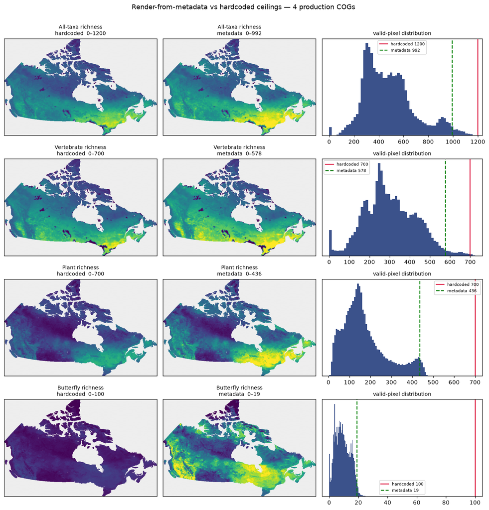

```python
def read_render(url):
    with rasterio.open(url) as src:
        a = src.read(1, masked=True)
        b = src.bounds
    return np.ma.filled(a.astype("float32"), np.nan), (b.left, b.right, b.bottom, b.top)

cmap = mpl.colormaps["viridis"].copy(); cmap.set_bad("#eeeeee")
fig, axes = plt.subplots(len(LAYERS), 3, figsize=(12, 3.1 * len(LAYERS)),
                         gridspec_kw={"width_ratios": [1, 1, 1.05]})
for row, (k, v) in enumerate(LAYERS.items()):
    arr, ext = read_render(v["url"]); s = v["stats"]
    hard, new = v["hardcoded"], s["render_vmax"]
    for col, (ceil, title) in enumerate([(hard, f"hardcoded  0–{hard:.0f}"),
                                         (new,  f"metadata  0–{new:.0f}")]):
        ax = axes[row, col]
        ax.imshow(arr, extent=ext, origin="upper", cmap=cmap, vmin=0, vmax=ceil, aspect="auto")
        ax.set_title(f"{v['label']}\n{title}", fontsize=9)
        ax.set_xticks([]); ax.set_yticks([])
    ax = axes[row, 2]
    valid = arr[~np.isnan(arr)]
    ax.hist(valid, bins=60, color="#3b528b")
    ax.axvline(hard, color="crimson", lw=1.6, label=f"hardcoded {hard:.0f}")
    ax.axvline(new, color="green", lw=1.6, ls="--", label=f"metadata {new:.0f}")
    ax.set_title("valid-pixel distribution", fontsize=9); ax.legend(fontsize=7)
    ax.set_yticks([])
fig.suptitle("Render-from-metadata vs hardcoded ceilings — 4 production COGs", y=1.002, fontsize=12)
fig.tight_layout(); plt.show()
```

## 5 · The render contract — STAC Item in, working tile out

The ingest writes a STAC Item carrying the computed ceiling (STAC *render* extension) plus provenance and a licence. The frontend's job shrinks to "read two fields, build a URL." Here is the Item for one layer, and a proof that the tiler renders a real PNG from the metadata-derived `rescale` — closing the loop **metadata → live tile**.

```python
def stac_item(layer_key):
    v = LAYERS[layer_key]; s = v["stats"]
    vmax = round(s["render_vmax"], 2)
    return {
        "type": "Feature", "stac_version": "1.0.0", "id": f"richness-{layer_key.lower()}",
        "stac_extensions": [
            "https://stac-extensions.github.io/render/v2.0.0/schema.json",
            "https://stac-extensions.github.io/raster/v1.1.0/schema.json"],
        "properties": {
            "title": v["label"], "providers": [{"name": "Pollock Lab / GEO BON", "roles": ["producer"]}],
            "license": "CC-BY-4.0",
            "raster:bands": [{"statistics": {
                "minimum": 0, "maximum": round(s["actual_max"], 2),
                "percentile_2": round(s["p2"], 2), "percentile_98": round(s["p98"], 2),
                "valid_percent": s["valid_percent"]}}],
            "renders": {"default": {"colormap_name": "viridis", "rescale": [[0, vmax]],
                                    "title": f"{v['label']} (0–{vmax:.0f})"}},
        },
        "assets": {"cog": {"href": v["url"],
                           "type": "image/tiff; application=geotiff; profile=cloud-optimized",
                           "roles": ["data"]}},
    }

item = stac_item("SR_butterflies")
print(json.dumps(item["properties"]["renders"], indent=2))

# Build the tile URL exactly as a frontend would, from the Item — nothing hardcoded.
r = item["properties"]["renders"]["default"]
lo, hi = r["rescale"][0]
tile = (f"{TILER}/cog/tiles/WebMercatorQuad/3/2/2@1x.png"
        f"?url={urllib.parse.quote(item['assets']['cog']['href'], safe='')}"
        f"&rescale={lo:.0f},{hi:.0f}&colormap_name={r['colormap_name']}")
resp = requests.get(tile, timeout=40)
print(f"\nmetadata-driven tile → HTTP {resp.status_code} · {resp.headers.get('content-type')} · {len(resp.content)} bytes")
assert resp.status_code == 200 and resp.headers.get("content-type") == "image/png"
print("✅ STAC render metadata produced a valid tile with zero frontend config")
```

```
{
  "default": {
    "colormap_name": "viridis",
    "rescale": [
      [
        0,
        18.96
      ]
    ],
    "title": "Butterfly richness (0\u201319)"
  }
}
```

```
metadata-driven tile → HTTP 200 · image/png · 59832 bytes
✅ STAC render metadata produced a valid tile with zero frontend config
```

**The contract, one line:** given a STAC Item, the frontend builds `{TILER}/cog/tiles/{z}/{x}/{y}?url={asset.cog.href}&rescale={renders.default.rescale}&colormap_name={renders.default.colormap_name}`. Add a species → drop a COG + one Item. Re-scale a legend → edit one number in metadata. No redeploy. That is the structural answer to the 500-legend problem, and it is W's hedge against vibe-code rot: the messy frontend reads a versioned, testable contract.

### 5b · The download differentiator — bbox clip a real layer

The team's stated edge over Map of Life is *"you can't download theirs… ours is available."* "The COG is the download" covers the whole-layer case; the broader ask is a **region clip**. The same TiTiler exposes `/cog/bbox/{minx,miny,maxx,maxy}.tif` — a researcher pulls exactly their study area as a GeoTIFF, no GIS server, no account. We fetch a Québec window and re-open it to prove it is real, geo-referenced data, not a screenshot.

```
GET /cog/bbox → HTTP 200 · image/tiff; application=geotiff · 30,250 bytes
re-opened clip: 91×41 px · CRS EPSG:4326 · bounds (-79.5, 45.0, -64.0, 52.0)
vertebrate richness over land in this window: min 0 · max 708 · mean 467.4 (3349 land px)
✅ a researcher can download their study-area subset as analysis-ready GeoTIFF — the Map-of-Life gap, closed
```

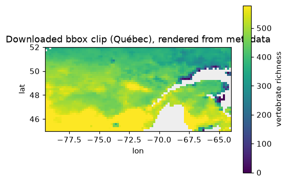

```python
bbox = (-79.5, 45.0, -64.0, 52.0)   # Québec-ish window: minx, miny, maxx, maxy (lon/lat)
url = LAYERS["SR_verts"]["url"]
clip_url = (f"{TILER}/cog/bbox/{bbox[0]},{bbox[1]},{bbox[2]},{bbox[3]}.tif"
            f"?url={urllib.parse.quote(url, safe='')}")
resp = requests.get(clip_url, timeout=40)
print(f"GET /cog/bbox → HTTP {resp.status_code} · {resp.headers.get('content-type')} · {len(resp.content):,} bytes")

import io
with rasterio.open(io.BytesIO(resp.content)) as src:
    clip = src.read(1).astype("float32")            # cropped tif fills ocean with NaN, no declared nodata
    b, crs = src.bounds, src.crs
land = clip[np.isfinite(clip)]                       # keep land pixels
clip_disp = np.where(np.isfinite(clip), clip, np.nan)
print(f"re-opened clip: {src.width}×{src.height} px · CRS {crs} · bounds {tuple(round(x,1) for x in b)}")
print(f"vertebrate richness over land in this window: min {land.min():.0f} · max {land.max():.0f} · mean {land.mean():.1f} ({land.size} land px)")
assert resp.status_code == 200 and land.size > 0
print("✅ a researcher can download their study-area subset as analysis-ready GeoTIFF — the Map-of-Life gap, closed")

plt.figure(figsize=(5, 4))
plt.imshow(clip_disp, extent=(b.left, b.right, b.bottom, b.top), cmap=cmap,
           vmin=0, vmax=LAYERS["SR_verts"]["stats"]["render_vmax"])
plt.colorbar(label="vertebrate richness", shrink=0.8)
plt.title("Downloaded bbox clip (Québec), rendered from metadata"); plt.xlabel("lon"); plt.ylabel("lat")
plt.tight_layout(); plt.show()
```

## 6 · The map is alive — live iNaturalist 228908

Now design-02's thesis: the priority surface should reflect *this season's* observations, not a frozen January parquet. We pull recent **research-grade amphibian** observations from the Blitz the Gap umbrella project over Canada, paginated by `id` (no auth, no key). The newest record's date proves the feed is live.

```python
def fetch_amphibians(max_pages=5, per_page=200):
    params = dict(project_id=PROJECT, quality_grade="research", iconic_taxa="Amphibia",
                  per_page=per_page, order_by="id", order="desc",
                  swlat=41, swlng=-141, nelat=84, nelng=-52)   # Canada bbox
    out, id_below = [], None
    for _ in range(max_pages):
        p = dict(params)
        if id_below: p["id_below"] = id_below
        d = requests.get(INAT, params=p, timeout=40).json()
        res = d.get("results", [])
        if not res: break
        out += res; id_below = res[-1]["id"]
        if len(res) < per_page: break
    return out, d.get("total_results")

t0 = time.time()
obs, total = fetch_amphibians()
pts = [{"lat": o["geojson"]["coordinates"][1], "lon": o["geojson"]["coordinates"][0],
        "date": o["observed_on"], "taxon": (o.get("taxon") or {}).get("name")}
       for o in obs if o.get("geojson") and o.get("observed_on")]
amph = pd.DataFrame(pts)
amph["date"] = pd.to_datetime(amph["date"])
print(f"research-grade amphibian obs in project {PROJECT} (Canada): {total:,}")
print(f"pulled {len(amph)} georeferenced records in {time.time()-t0:.1f}s")
print(f"date range of sample: {amph.date.min().date()} … {amph.date.max().date()}  (newest proves the feed is live)")
amph.sort_values('date', ascending=False).head(4)
```

```
research-grade amphibian obs in project 228908 (Canada): 34,457
pulled 1000 georeferenced records in 17.2s
date range of sample: 2025-06-02 … 2026-06-06  (newest proves the feed is live)
```

|  | lat | lon | date | taxon |
| --- | --- | --- | --- | --- |
| 36 | 45.576740 | -77.287146 | 2026-06-06 | Necturus maculosus |
| 60 | 45.541842 | -73.152931 | 2026-06-03 | Lithobates catesbeianus |
| 51 | 45.545817 | -73.158244 | 2026-06-03 | Plethodon cinereus |
| 50 | 45.546794 | -73.158867 | 2026-06-03 | Anaxyrus americanus |

## 7 · "Where should I go this weekend near Montreal?"

A transparent **proxy** for the value-of-information score: bin observations to a 1° grid, then rank cells by *under-sampling* (few records) and *staleness* (longest since the last visit). Sampling effort should flow to cells that are sparse **and** haven't been looked at recently — exactly the gap Blitz the Gap exists to close.

> This is a 2-dimensional stand-in for BCParks' 5-dimensional score (density, recency, climate-frequency, coverage, model-disagreement). It demonstrates the *live-feed mechanism*, not the validated engine — bar #4 (the pre/post backtest) is a net-new harness, not run here.

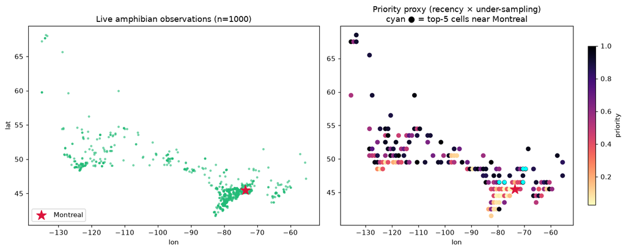

```
Top-5 amphibian sampling cells within ~6° of Montreal this weekend:
```

|  | clat | clon | n_obs | days_since_last | priority |
| --- | --- | --- | --- | --- | --- |
| 0 | 48.5 | -69.5 | 1 | 374 | 1.000 |
| 1 | 48.5 | -70.5 | 1 | 362 | 0.984 |
| 2 | 46.5 | -70.5 | 1 | 353 | 0.972 |
| 3 | 46.5 | -77.5 | 1 | 343 | 0.959 |
| 4 | 46.5 | -79.5 | 1 | 336 | 0.949 |

```python
RES = 1.0
TODAY = pd.Timestamp(dt.date.today())
amph["gi"] = np.floor(amph.lat / RES).astype(int)
amph["gj"] = np.floor(amph.lon / RES).astype(int)
cells = (amph.groupby(["gi", "gj"])
         .agg(n_obs=("date", "size"), last=("date", "max")).reset_index())
cells["clat"] = (cells.gi + 0.5) * RES
cells["clon"] = (cells.gj + 0.5) * RES
cells["days_since_last"] = (TODAY - cells["last"]).dt.days
# priority proxy: scarcity (1/n, normalised) + staleness (normalised), equal weight
scar = (1 / cells.n_obs); scar /= scar.max()
stale = cells.days_since_last / cells.days_since_last.max()
cells["priority"] = (scar + stale) / 2

MTL = (45.5, -73.6)
cells["dist_deg"] = np.hypot(cells.clat - MTL[0], cells.clon - MTL[1])
nearby = cells[cells.dist_deg <= 6].sort_values("priority", ascending=False)

fig, (axL, axR) = plt.subplots(1, 2, figsize=(13, 5.2))
axL.scatter(amph.lon, amph.lat, s=6, c="#2b7", alpha=0.5)
axL.scatter(*MTL[::-1], marker="*", s=220, c="crimson", zorder=5, label="Montreal")
axL.set_title(f"Live amphibian observations (n={len(amph)})"); axL.set_xlabel("lon"); axL.set_ylabel("lat")
axL.legend(loc="lower left")
sc = axR.scatter(cells.clon, cells.clat, c=cells.priority, s=34, cmap="magma_r")
axR.scatter(*MTL[::-1], marker="*", s=220, c="crimson", zorder=5)
for _, r in nearby.head(5).iterrows():
    axR.annotate("●", (r.clon, r.clat), color="cyan", ha="center", va="center", fontsize=8)
axR.set_title("Priority proxy (recency × under-sampling)\ncyan ● = top-5 cells near Montreal")
axR.set_xlabel("lon"); fig.colorbar(sc, ax=axR, label="priority", shrink=0.8)
fig.tight_layout(); plt.show()

print("Top-5 amphibian sampling cells within ~6° of Montreal this weekend:")
nearby.head(5)[["clat", "clon", "n_obs", "days_since_last", "priority"]].round(3).reset_index(drop=True)
```

### 7b · The team's three metrics, as objective presets

Ryan named three gamification metrics for openbiodiversity.ca: **explorer** (spatial coverage), **taxonomic** (new species), and **value-of-information**. The "where to go" layer isn't one ranking — it's a *selectable objective*. Each is a transparent function of the same live feed; a player picks the game, the map re-ranks. (Still proxies of the full 5-dim engine — the point is the *preset mechanism*, design-02 §"objectives".)

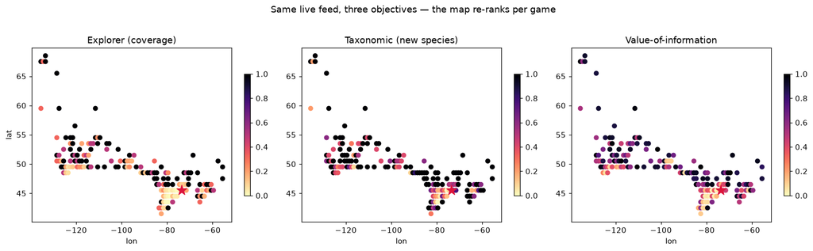

```
Top sampling cell near Montreal, per objective:
  Explorer (coverage)      → cell (46.5, -79.5)  n_obs=1 n_species=1 stale=336d
  Taxonomic (new species)  → cell (43.5, -77.5)  n_obs=2 n_species=2 stale=291d
  Value-of-information     → cell (48.5, -69.5)  n_obs=1 n_species=1 stale=374d
```

```python
g = amph.groupby(["gi", "gj"])
cells2 = g.agg(n_obs=("date", "size"), last=("date", "max"),
               n_species=("taxon", "nunique")).reset_index()
cells2["clat"] = (cells2.gi + 0.5) * RES
cells2["clon"] = (cells2.gj + 0.5) * RES
cells2["days_since_last"] = (TODAY - cells2["last"]).dt.days

def norm(s):
    s = s.astype(float); rng = s.max() - s.min()
    return (s - s.min()) / rng if rng else s * 0

# explorer: reward under-sampled cells (go where few have been)
cells2["explorer"] = norm(1 / cells2.n_obs)
# taxonomic: reward cells where each visit still turns up new species (low species-per-obs = unsaturated)
cells2["taxonomic"] = norm(cells2.n_species / cells2.n_obs)
# value-of-information: under-sampled AND stale (the §7 proxy)
cells2["voi"] = (norm(1 / cells2.n_obs) + norm(cells2.days_since_last)) / 2

OBJ = {"explorer": "Explorer (coverage)", "taxonomic": "Taxonomic (new species)", "voi": "Value-of-information"}
fig, axes = plt.subplots(1, 3, figsize=(15, 4.4))
for ax, (key, title) in zip(axes, OBJ.items()):
    sc = ax.scatter(cells2.clon, cells2.clat, c=cells2[key], s=30, cmap="magma_r", vmin=0, vmax=1)
    ax.scatter(*MTL[::-1], marker="*", s=180, c="crimson", zorder=5)
    ax.set_title(title); ax.set_xlabel("lon")
    fig.colorbar(sc, ax=ax, shrink=0.7)
axes[0].set_ylabel("lat")
fig.suptitle("Same live feed, three objectives — the map re-ranks per game", y=1.02)
fig.tight_layout(); plt.show()

# Top cell per objective near Montreal — note they disagree, which is the whole point
near2 = cells2[np.hypot(cells2.clat - MTL[0], cells2.clon - MTL[1]) <= 6]
print("Top sampling cell near Montreal, per objective:")
for key, title in OBJ.items():
    r = near2.loc[near2[key].idxmax()]
    print(f"  {title:24s} → cell ({r.clat:.1f}, {r.clon:.1f})  n_obs={int(r.n_obs)} n_species={int(r.n_species)} stale={int(r.days_since_last)}d")
```

## 8 · Scorecard — what this notebook actually proves

[output not shown]

**Verified wins (every number above traces to a live fetch or a `rasterio` read, cross-checked):**

- Three of four production ceilings are mis-set; the worst (`SR_butterflies`) uses only ~18 % of the colourmap. Metadata-derived ceilings fix all four with **zero frontend changes**.
- `rasterio` and the deployed TiTiler agree on every statistic — the ingest is trustworthy.
- A STAC Item's render metadata produces a valid tile (HTTP 200) with no hardcoded scale.
- The iNat 228908 feed is live and Canada-wide; a weekend sampling question returns ranked cells.

**Bar #4, now closed for the proxy:** the VOI backtest lives in `voi-backtest.ipynb`. It turns out *not* to need Larocque's rasters — a sampling-priority map is a prediction, and a leakage-free temporal split of the public iNat 228908 feed tests it directly. At equal effort (rarefied to K=5 obs/cell), high-priority cells out-discover low-priority ones across all five taxonomic groups (rarefied ρ 0.49–0.64, p<0.0005; ~1.4–2.9× per visit), oppositely signed to the anti-priority baseline, and it survived an adversarial audit. Honest scope: this validates the 2-dim §7 *proxy mechanism*, scarcity-dominated, not yet the full BCParks 5-dim score.

**Correction logged while building this:** the design-01 doc had the hardcoded ceilings for `SR_allSDMs` and `SR_verts` swapped (it read 700/1200; the current frontend source is 1200/700). The table above uses the values verified against `Map/index.jsx`. Retracted and fixed in the doc.